# EVOLUCIÓN DE LA POBREZA Y LA INDIGENCIA

Martin Gonzalez-Rozada.  
Director de la Maestría en Econometría del Departamento de Economía de la [Universidad Torcuato Di Tella](https://www.utdt.edu/).

Primer Semestre 2025.  
*2025 - Año de la Primera Estrella*

**En el primer semestre de 2025, en el total de los 31 aglomerados urbanos capturados por la Encuesta Permanente de Hogares, la tasa de pobreza fue de 31.6 por ciento y la de indigencia 6.9 por ciento. Esto implica una caída de 21.3 puntos porcentuales en la pobreza y de 11.2 puntos porcentuales en la indigencia comparadas con el primer semestre de 2024.**

**Figura 1. Incidencia de la Pobreza y la Indigencia (en porcentaje). Total de Aglomerados**

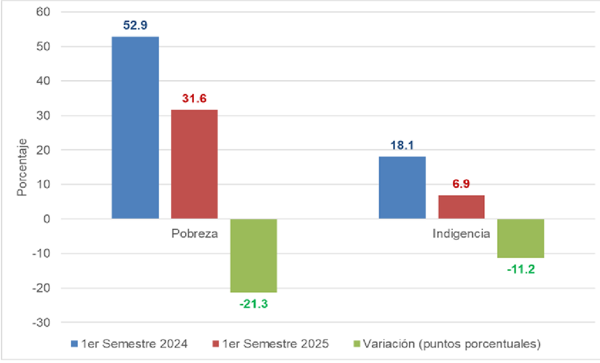

Fuente: elaboración propia a partir de la Encuesta Permanente de Hogares (EPH)

**Pobreza e Indigencia por Área Geográfica**

**Región del Gran Buenos Aires:** la caída en la pobreza y la indigencia se explica principalmente por la situación en los partidos del conurbano bonaerense donde la tasa de pobreza pasó de 59.7 a 35.3 por ciento y la de indigencia de 22.7 a 8.8 por ciento. En la Ciudad Autónoma de Buenos Aires la tasa de pobreza cayó 8.0 puntos porcentuales y la de indigencia 4.0 puntos porcentuales (Cuadros 1 y 3). La caída interanual de la pobreza en los partidos del conurbano implicó que en el primer semestre de 2025 haya 3.1 millones de personas menos, que en el primero de 2024, que viven en hogares pobres (Cuadro 2).

**Región Cuyo:** la incidencia de la pobreza disminuyó 18.5 puntos porcentuales entre el primer semestre de 2024 y el primero de 2025. La caída fue impulsado por el aglomerado del Gran San Luis, donde la pobreza cayó más de 23 puntos porcentuales. Por otro lado, en el Gran San Juan la pobreza se cayó 14.5 puntos porcentuales pasando de 50.5 por ciento en el primer semestre de 2024 a 36.0 por ciento en el primero de 2025 (Cuadro 1). En esta región, la caída de la indigencia en términos interanuales fue d 9.0 puntos porcentuales liderada por los aglomerados de Gran Mendoza y Gran San Juan.

**Región Noroeste:** la tasa de pobreza pasó de 57.0 por ciento a 31.2 por ciento y la tasa de indigencia indigencia de 17.2 por ciento a 4.4 por ciento entre el primer semestre de 2024 y el primero de 2025. La caída interanual en la indigencia fue impulsada por el aglomerado de Santiago del Estero - La Banda donde cayó alrededor de 18 puntos porcentuales; mientras que la caída de la pobreza se explica por lo ocurrido en los aglomerados de Santiago del Estero - La Banda y La Rioja donde cayó más de 30 puntos porcentuales. En La Rioja pasó de 66.4 por ciento en el primer semestre de 2024 a 32.4 por ciento en el primero de 2025 (Cuadros 1 y 3).

**Región Pampeana:** la tasa de pobreza cayó casi 20 puntos porcentuales en la comparación con el primer semestre de 2024 alcanzando 30.5 por ciento en el primer semestre de 2025; mientras que la incidencia de la indigencia llegó al 6.4 por ciento en el primer semestre de 2025 (Cuadros 1 y 3). La caída de la pobreza fue homogénea en los aglomerados que componen la región. Pueden destacarse los aglomerados de Santa Rosa - Toay que es donde menos caída hubo, mientras que en el aglomerado de Río Cuarto la pobreza cayó casi 30 puntos porcentuales ubicándose en 24.4 por ciento en el primer semestre de 2025 (Cuadro 1). La tasa de indigencia llegó a 6.4 por ciento en el primer semestre de 2025 impulsada por la caída en los aglomerados de Concordia y San Nicolás -Villa Constitución (Cuadro 3).

**Región Patagonia:** la ´pobreza tuvo una caída de 22.1 puntos porcentuales miestras que la indigencia cayó 7.3 puntos porcentuales en comparación con el primer semestre de 2024. Ambas caídas resultaron estadísticamente significativas (Cuadros 1 y 3). En términos poblacionales la pobreza cayó en todos los aglomerados de la región y fue liderada por el aglomeradoViedma - Carmen de Patagones (Cuadro 1). La caída de la indigencia fue impulsada por la disminución en el aglomerados Rawson - Trelew donde pasó de 13.1 por ciento a 3.5 por ciento entre el primer semestre de 2024 y el primero de 2025 (Cuadro 3).

**Cuadro 1: evolución de la pobreza por aglomerado**

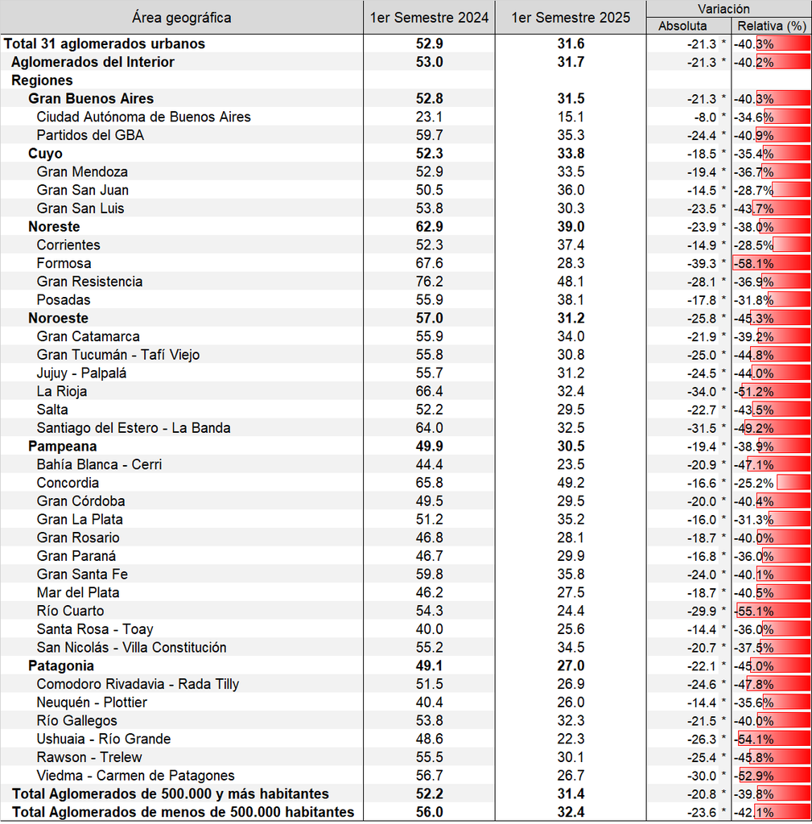

Nota: * indica que la variación es estadísticamente significativa al 5%.

**Cuadro 2: personas que viven en hogares pobres**

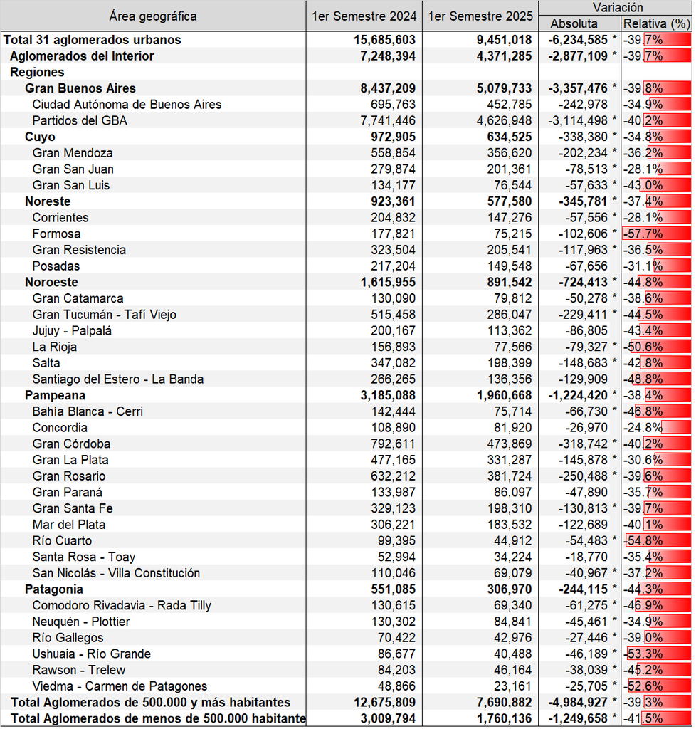

Nota: * indica que la variación es estadísticamente significativa al 5%.

**Cuadro 3: evolución de la indigencia por aglomerado**

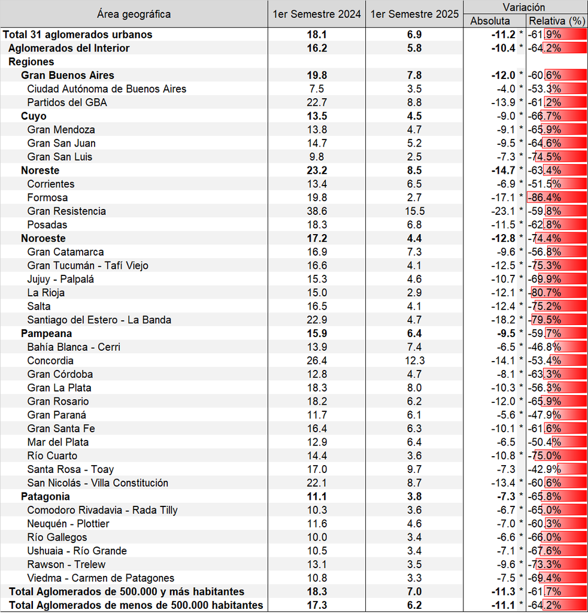

Nota: * indica que la variación es estadísticamente significativa al 5%.

**Cuadro 4: personas que viven en hogares indigentes**

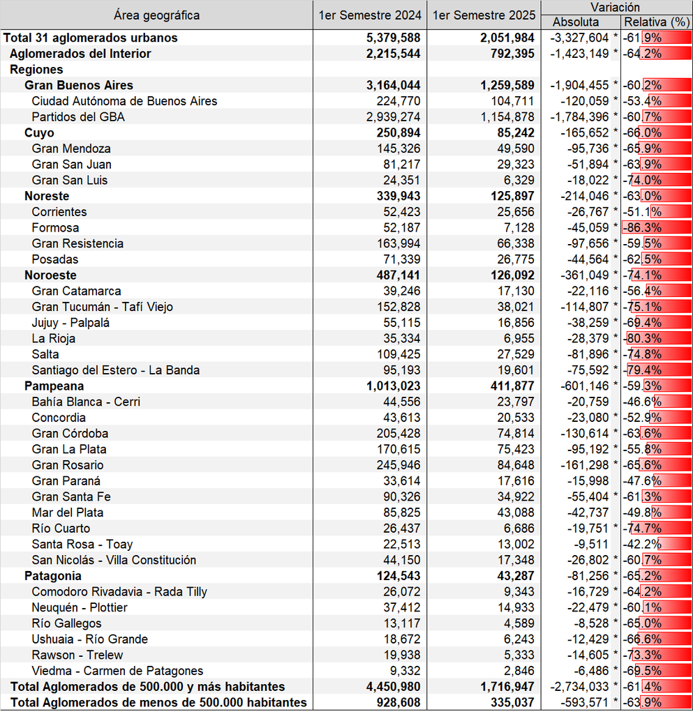

Nota: * indica que la variación es estadísticamente significativa al 5%.

**Menores de Edad según Condición de Pobreza**

El porcentaje de menores de 18 años que viven en hogares pobres alcanzó en el primer semestre de 2025 el 46.1 por ciento. Esto es una caída de 21 puntos porcentuales con respecto al primer semestre de 2024. Esta caída fue impulsada por el porcentaje de menores de 18 años que viven en hogares indigentes que cayó de 27.3 por ciento en el primer semestre de 2024 al 10.2 por ciento en el primero de 2025. El porcentaje de pobres no indigentes se mantuvo relativamente estable entre esos dos semestres. Si se desagrega por grupos de edad el comportamiento es homogéneo. En los tres grupos (0 a 5, 6 a 11 y 12 a 17 años) se observa el mismo fenómeno, el porcentaje de menores que viven en hogares pobres cae porque caen quienes viven en hogares indigentes (Cuadro 5).

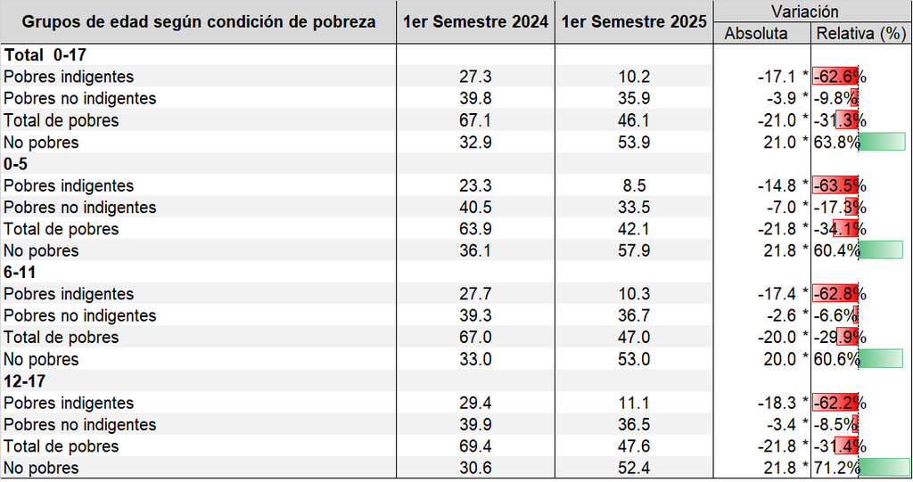

Nota: * indica que la variación es estadísticamente significativa al 5%.